# Class 10 - In class exercises

Hari Subhash

Date created: 2019-04-09

# notes

when need to see number of obs in a group

summarise(nObs = n()) nObs is a name we made up for a new column, but n() just counts the number of obs when you have no args depends on having group_by done first

Note from lecture - for weather origin month day hour group still does not return unique values time_hour does better, hour creates daylight_savings duplicates

NOTE - in weathered_flights in lecture, the first plot we get looks weird and maybe sample size is the problem

## Task 1: Examine the weather data

1. Use the `skim()` function from the `skimr` package to visually display all the variables in weather

```r
skim(flights)
```

[output not shown]

2. Use `nrow()` to display the number of rows in the weather data

```r
nrow(weather)
```

```
[1] 26115
```

3. Use `dim()` to display the rows and columns of the weather data

```r
dim(weather)
```

```
[1] 26115    15
```

4. Use `names()` to display the column names of the weather data

```r
names(weather)
```

```
 [1] "origin"     "year"       "month"      "day"        "hour"       "temp"       "dewp"       "humid"      "wind_dir"
[10] "wind_speed" "wind_gust"  "precip"     "pressure"   "visib"      "time_hour"
```

5. Display the `head()` of the weather data

| origin | year | month | day | hour | temp | dewp | humid | wind_dir | wind_speed | wind_gust | precip | pressure | visib | time_hour |
| --- | --- | --- | --- | --- | --- | --- | --- | --- | --- | --- | --- | --- | --- | --- |
| EWR | 2013 | 1 | 1 | 1 | 39.02 | 26.06 | 59.37 | 270 | 10.35702 | NA | 0 | 1012.0 | 10 | 2013-01-01 01:00:00 |
| EWR | 2013 | 1 | 1 | 2 | 39.02 | 26.96 | 61.63 | 250 | 8.05546 | NA | 0 | 1012.3 | 10 | 2013-01-01 02:00:00 |
| EWR | 2013 | 1 | 1 | 3 | 39.02 | 28.04 | 64.43 | 240 | 11.50780 | NA | 0 | 1012.5 | 10 | 2013-01-01 03:00:00 |
| EWR | 2013 | 1 | 1 | 4 | 39.92 | 28.04 | 62.21 | 250 | 12.65858 | NA | 0 | 1012.2 | 10 | 2013-01-01 04:00:00 |
| EWR | 2013 | 1 | 1 | 5 | 39.02 | 28.04 | 64.43 | 260 | 12.65858 | NA | 0 | 1011.9 | 10 | 2013-01-01 05:00:00 |
| EWR | 2013 | 1 | 1 | 6 | 37.94 | 28.04 | 67.21 | 240 | 11.50780 | NA | 0 | 1012.4 | 10 | 2013-01-01 06:00:00 |

6. Display the `tail()` of the weather data

| origin | year | month | day | hour | temp | dewp | humid | wind_dir | wind_speed | wind_gust | precip | pressure | visib | time_hour |
| --- | --- | --- | --- | --- | --- | --- | --- | --- | --- | --- | --- | --- | --- | --- |
| LGA | 2013 | 12 | 30 | 13 | 37.04 | 21.92 | 53.97 | 340 | 17.26170 | 20.71404 | 0 | 1016.5 | 10 | 2013-12-30 13:00:00 |
| LGA | 2013 | 12 | 30 | 14 | 35.96 | 19.94 | 51.78 | 340 | 13.80936 | 21.86482 | 0 | 1017.1 | 10 | 2013-12-30 14:00:00 |
| LGA | 2013 | 12 | 30 | 15 | 33.98 | 17.06 | 49.51 | 330 | 17.26170 | 21.86482 | 0 | 1018.8 | 10 | 2013-12-30 15:00:00 |
| LGA | 2013 | 12 | 30 | 16 | 32.00 | 15.08 | 49.19 | 340 | 14.96014 | 23.01560 | 0 | 1019.5 | 10 | 2013-12-30 16:00:00 |
| LGA | 2013 | 12 | 30 | 17 | 30.92 | 12.92 | 46.74 | 320 | 17.26170 | NA | 0 | 1019.9 | 10 | 2013-12-30 17:00:00 |
| LGA | 2013 | 12 | 30 | 18 | 28.94 | 10.94 | 46.41 | 330 | 18.41248 | NA | 0 | 1020.9 | 10 | 2013-12-30 18:00:00 |

7. Display a random 10 rows from the weather data using `sample_n()`

| origin | year | month | day | hour | temp | dewp | humid | wind_dir | wind_speed | wind_gust | precip | pressure | visib | time_hour |
| --- | --- | --- | --- | --- | --- | --- | --- | --- | --- | --- | --- | --- | --- | --- |
| LGA | 2013 | 10 | 9 | 3 | 57.92 | 44.06 | 59.84 | 30 | 12.65858 | NA | 0.00 | 1027.1 | 10 | 2013-10-09 03:00:00 |
| JFK | 2013 | 12 | 17 | 3 | 28.04 | 8.96 | 44.07 | 60 | 5.75390 | NA | 0.00 | 1023.0 | 10 | 2013-12-17 03:00:00 |
| JFK | 2013 | 11 | 30 | 19 | 37.04 | 26.06 | 64.46 | 60 | 8.05546 | NA | 0.00 | NA | 10 | 2013-11-30 19:00:00 |
| JFK | 2013 | 2 | 2 | 17 | 28.04 | 6.98 | 40.31 | 230 | 13.80936 | NA | 0.00 | 1019.8 | 10 | 2013-02-02 17:00:00 |
| JFK | 2013 | 5 | 6 | 0 | 46.40 | 41.00 | 82.45 | 50 | 6.90468 | NA | 0.00 | NA | 10 | 2013-05-06 00:00:00 |
| JFK | 2013 | 6 | 14 | 14 | 71.06 | 51.98 | 50.89 | 340 | 5.75390 | NA | 0.00 | 1009.1 | 10 | 2013-06-14 14:00:00 |
| EWR | 2013 | 7 | 23 | 4 | 77.00 | 75.20 | 94.19 | 180 | 11.50780 | NA | 0.13 | NA | 7 | 2013-07-23 04:00:00 |
| JFK | 2013 | 8 | 28 | 7 | 75.02 | 69.08 | 81.79 | 0 | 0.00000 | NA | 0.00 | 1012.1 | 9 | 2013-08-28 07:00:00 |
| EWR | 2013 | 5 | 10 | 12 | 78.08 | 53.96 | 43.26 | NA | 5.75390 | NA | 0.00 | 1014.6 | 10 | 2013-05-10 12:00:00 |
| LGA | 2013 | 11 | 7 | 3 | 59.00 | 53.96 | 83.34 | 0 | 0.00000 | NA | 0.00 | 1014.4 | 10 | 2013-11-07 03:00:00 |

8. What are the primary keys of the weather data? i.e. which column(s) can be used to uniquely identify each observation in the weather data? Hint: `group_by()` with `filter(n() > 1)` to check if there are more than one observation per group.

ME: as is this returns values for these groups, which means they do have N > 1, more than 1 obs per value, so this is not primary key see below There is no single var primary key, use origin + time hour

| origin | year | month | day | hour | temp | dewp | humid | wind_dir | wind_speed | wind_gust | precip | pressure | visib | time_hour |
| --- | --- | --- | --- | --- | --- | --- | --- | --- | --- | --- | --- | --- | --- | --- |
| EWR | 2013 | 1 | 1 | 1 | 39.02 | 26.06 | 59.37 | 270 | 10.35702 | NA | 0.00 | 1012.0 | 10.00 | 2013-01-01 01:00:00 |
| EWR | 2013 | 1 | 1 | 2 | 39.02 | 26.96 | 61.63 | 250 | 8.05546 | NA | 0.00 | 1012.3 | 10.00 | 2013-01-01 02:00:00 |
| EWR | 2013 | 1 | 1 | 3 | 39.02 | 28.04 | 64.43 | 240 | 11.50780 | NA | 0.00 | 1012.5 | 10.00 | 2013-01-01 03:00:00 |
| EWR | 2013 | 1 | 1 | 4 | 39.92 | 28.04 | 62.21 | 250 | 12.65858 | NA | 0.00 | 1012.2 | 10.00 | 2013-01-01 04:00:00 |
| EWR | 2013 | 1 | 1 | 5 | 39.02 | 28.04 | 64.43 | 260 | 12.65858 | NA | 0.00 | 1011.9 | 10.00 | 2013-01-01 05:00:00 |
| EWR | 2013 | 1 | 1 | 6 | 37.94 | 28.04 | 67.21 | 240 | 11.50780 | NA | 0.00 | 1012.4 | 10.00 | 2013-01-01 06:00:00 |
| EWR | 2013 | 1 | 1 | 7 | 39.02 | 28.04 | 64.43 | 240 | 14.96014 | NA | 0.00 | 1012.2 | 10.00 | 2013-01-01 07:00:00 |
| EWR | 2013 | 1 | 1 | 8 | 39.92 | 28.04 | 62.21 | 250 | 10.35702 | NA | 0.00 | 1012.2 | 10.00 | 2013-01-01 08:00:00 |
| EWR | 2013 | 1 | 1 | 9 | 39.92 | 28.04 | 62.21 | 260 | 14.96014 | NA | 0.00 | 1012.7 | 10.00 | 2013-01-01 09:00:00 |
| EWR | 2013 | 1 | 1 | 10 | 41.00 | 28.04 | 59.65 | 260 | 13.80936 | NA | 0.00 | 1012.4 | 10.00 | 2013-01-01 10:00:00 |

[output cut: 990 more lines]

## Task 2: Explore the indepedent variable

Use a combination of text, tables and charts to explore the nature of the independent variable ME: should have used skimr! This isn’t much info

```r
#weather %>%
 # summary(wind_gust)
summary(weather$wind_gust)
```

```
   Min. 1st Qu.  Median    Mean 3rd Qu.    Max.    NA's
  16.11   20.71   24.17   25.49   28.77   66.75   20778
```

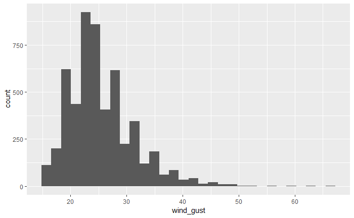

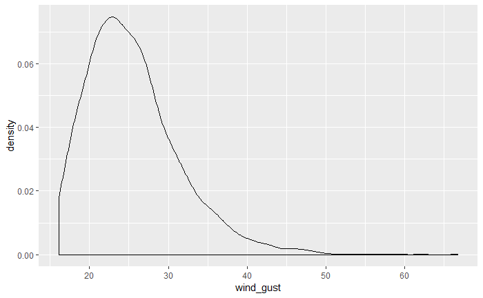

| binned_delay | nObs |
| --- | --- |
| [13.5,16.5] | 113 |
| (16.5,19.5] | 495 |
| (19.5,22.5] | 1203 |
| (22.5,25.5] | 1343 |
| (25.5,28.5] | 761 |
| (28.5,31.5] | 678 |
| (31.5,34.5] | 274 |
| (34.5,37.5] | 244 |
| (37.5,40.5] | 120 |
| (40.5,43.5] | 43 |

[output cut: 7 more lines]

## Task 3. Explore a relationship

Explore the relationship between departure delay and a variable of your choice.